# RSV (AREXVY) - Needle issue

OpenSourcePV

Data Lock Point: Data contains VAERS reports processed as of 2023_11_24 (Year_Month_Day). Flag NEW was defined against reports processed as of 2023_10_27.

# 1 Quantitative Signal status

## 1.1 Disproportionality

The vaccine-event combination “RSV (AREXVY) - Needle issue” was **a signal of disproportionate reporting** with an EB05 value of 2.14.

The threshold for being flagged as a signal of disproportionate reporting is an EB05>=2 meaning that there there is a 95% probability that the reporting of Needle issue was at least twice post exposure to RSV (AREXVY) than post all vaccines. Under the assumption of no causality between RSV (AREXVY) and Needle issue and no bias it would have been expected to observe an EBGM of 1.

It means that the quantified causality criterion of strength of association is **met**.

*It is to be noted that the nature of the spontaneous report does not provide reliable estimates of the strength of association (whatever the choice of the disproportionality method) and that some reporting bias or difference in demographic characteristics might explain the (un)observed disproportion*.

## 1.2 Time-to-onset

The vaccine-event combination “RSV (AREXVY) - Needle issue” was **not a signal of unexpected time-to-onset distribution** with a p-value of the two-sample Kolmogorov-Smirnov test being 1 and distance between the two empirical cumulative distributions being of 4.5031056%.

The threshold for being flagged as a signal of unexpected time-to-onset distribution is a P-value of the two-sample Kolmogorov-Smirnov test <0.001 and a distance between the two empirical distributions larger than 20%. Under the assumption of no causality and no bias, it would have been expected that the time-to-onset distribution for “Needle issue” would have been the same post RSV (AREXVY) than post other vaccines. The two-sample Kolmogorov-Smirnov tests this hypothesis.

It means that the quantified causality criterion of temporality is **not met**.

*It is to be noted that the nature of the spontaneous report does not provide reliable estimates of the temporal relationship between the exposure and the occurrence of the events as there is the reporting bias over time: the latter the event occurs after exposure, the less chance it has to be reported. Other biases could distort the reported time-to-onset distribution (media attention, etc.)*

## 1.3 Overall

Based on the screening of the Empirical Bayes Geometric Mean (EBGM) and the screening of the time-to-onset distribution,the vaccine-event combination “RSV (AREXVY) - Needle issue” is **considered as quantitative signal**.

# 2 Signal History

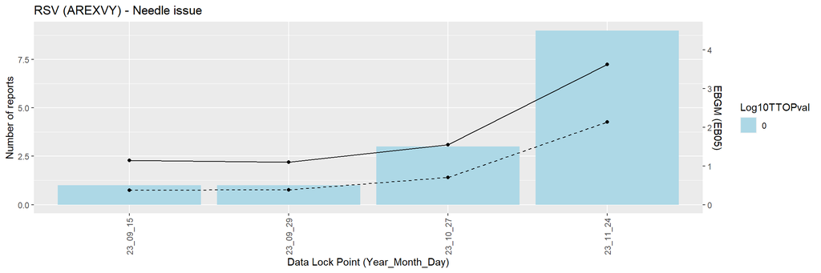

# 3 Case series

## 3.1 Seriousness

A total of 9 reports of Needle issue were received post exposure to RSV (AREXVY). Among them:

- 0 (0.0 %) were fatal cases.
- 0 (0.0 %) were life threatening cases.
- 0 (0.0 %) were hospitalized cases.
- 0 (0.0 %) were emergency room cases.
- 0 (0.0 %) were cases with disabilies.

6 new cases were received since last data refresh.

## 3.2 Demographic characteristics

9 cases of Needle issue post RSV (AREXVY) were reported in VAERS:

- Among them, there were 5 (55.6%) female cases and 3 (33.3%) male cases while the overall female:male ratio is 69:26%.
- The mean (median) age for patients presenting symptoms of Needle issue was 73 (75) years while the overall mean (median) age was 71 (71) years.
- The top 5 contributing US states for patients presenting symptoms of Needle issue were NY ( 33.3 %) , CA ( 11.1 %) , CT ( 11.1 %) , MS ( 11.1 %) , NJ ( 11.1 %) while overall the top 5 of contributing US states are NA ( 11.1 %) , FL ( 10.2 %) , CA ( 8.5 %) , NY ( 6.1 %) , TX ( 4.2 %)

# 4 Listing of the cases

Narratives can be made visible clicking on the ⊕ symbol.

|  | VAERS_ID | Sex/Age (Years) | Receipt Date | Seriousness status | List of symptoms | new | SYMPTOM_TEXT |
| --- | --- | --- | --- | --- | --- | --- | --- |
| &oplus; | 2679265 | M/78 | 09/05/2023 |  | Accidental underdose, Needle issue | No | dose was partially administered the needle detached from the syringe This non serious case was reported by a other health professional via call center representative and described the occurrence of ac… |
| &oplus; | 2688812 | U/NA | 09/29/2023 |  | Accidental exposure to product, Accidental underdose, Exposure via skin contact, Needle issue, Underdose | No | patient received under dose of medication needle broke off Arexvy leaked out onto the patient skin Arexvy leaked out onto the patient skin This non serious case was reported by a pharmacist via call c… |
| &oplus; | 2688836 | M/63 | 09/29/2023 |  | Incorrect dose administered, Needle issue | No | Incomplete dose part of a dose of Arexvy leaked from the needle This non serious case was reported by a pharmacist via call center representative and described the occurrence of incomplete dose admini… |
| &oplus; | 2705469 | F/75 | 10/30/2023 |  | Incorrect dose administered, Needle issue, Underdose | Yes | while vaccinating a patient with Arexvy a couple drops squirted out at the end onto pharmacists glove This non serious case was reported by a pharmacist via call center representative and described th… |
| &oplus; | 2707905 | F/NA | 11/01/2023 |  | Incorrect dose administered, Needle issue | Yes | underdose 3 4 days ago a female patient received a dose of Arexvy that leaked out the needle during administration This non serious case was reported by a pharmacist via call center representative and… |
| &oplus; | 2709036 | M/NA | 11/03/2023 |  | Incorrect dose administered, Needle issue, Product preparation issue | Yes | Inappropriate reconstitution technique Incorrect dose administered leaked out of the needle puncture This non serious case was reported by a pharmacist via call center representative and described the… |
| &oplus; | 2710449 | F/75 | 11/06/2023 |  | Device connection issue, Needle issue, No adverse event, Underdose | Yes | there was needle leakage patient did not receive full dose This non serious case was reported by a pharmacist via call center representative and described the occurrence of incomplete dose administere… |
| &oplus; | 2710471 | F/76 | 11/06/2023 |  | Exposure via skin contact, Needle issue, Underdose | Yes | the administration of Arexvy 4 drops leaked through the needle drops were in contact with patients arm drops were in contact with patients arm This non serious case was reported by a pharmacist via ca… |
| &oplus; | 2715800 | F/NA | 11/20/2023 |  | Exposure via skin contact, Needle issue, Underdose | Yes | during administration of Arexvy the needle leaked vaccine out onto the patients arm and she did not get a full dose during administration of Arexvy the needle leaked vaccine out onto the patients arm … |

# 5 Disclaimer

This analysis is exploratory only and authors cannot be held responsible for any decision made using these data. It is important to distinguish quantitative signals such as disproportionate reporting, unexpected time-to-onset patterns or cluster from safety signals. Only a qualitative review using multiple data source (literature, clinical trials, etc.) and multiple causality criteria assessment could qualify quantitative signals into safety signals.